# Sensitivity Analysis

Sensitivity analysis is an essential part of any competent statistical analysis. Unfortunately, it also tends to be overlooked in many academic papers, either due to a lack of familiarity with modern techniques, or worse, an unwillingness to jeopardize seemingly positive initial results by introducing possible confounders. Yet as statistics driven endeavors expand their scope due to the explosion of Big Data, it becomes increasingly necessary to incorporate sensitivity analysis so that companies and labs are not misled by spurious observations.

In the following project, we will first discuss some of the theory behind unseen confounders and their possible effects on regression. Then we will use these ideas as well as the *sensemakr* package to reproduce the results found in the paper “Who Supports Peace with the FARC? A Sensitivity-Based Approach under Imperfect Identification” by Hazlett and Parente (2020).

# Omitted Variables

## Simple Bias

Let’s suppose we are testing the effect of a treatment $D$ on some response $Y$, using data containing known covariates $X$. Assuming we have preprocessed our data appropriately for the problem at hand, we decide to model the effect with a simple regression:

$$Y = \hat{\tau}_{res} D+\hat{\beta}_{res} X + \hat\epsilon_{res}$$
From the regression, we will read out the coefficients $\hat{\tau}_{res},\hat{\beta}_{res}$, and the error $\hat\epsilon_{res}$.

This result is all well and good given the data we have collected. But what about the data we *didn’t* collect? More precisely, suppose that, unbeknownst to us, there is another covariate $Z$ that has a significant effect on our dataset as a whole. In this case, the true model of the data would be:

$$Y=\hat{\tau}D+\hat{\beta}X+\hat{\gamma}Z+\hat{\epsilon}_{full}$$

In other words, our *measured* coefficients ($\hat{\tau}_{res},\hat{\beta}_{res},and ~\hat\epsilon_{res}$) differ from the *true* coefficients ($\hat{\tau},\hat{\beta},and~ \hat\epsilon$). Our goal then is to attempt to estimate the true coefficients given our imperfect measurements.

To proceed, we will focus primarily on the treatment effect ($\hat{\tau}$). First, we will want to use a nice trick to simplify our original regression. Let $M_X=I-X(X^TX)^{-1}X$ be the annihilator matrix for $X$ (that is, $M_XX=0$). By the *FWL theorem*, we have:
$$M_XY=\hat{\tau}_{res}M_XD + M_X\hat{\epsilon}_{res}$$
Notice how we have eliminated the $X$ term entirely while the $D$ regression coefficient is unchanged. Now $\hat{\tau}_{res}$ is found by minimizing the RSS:
$$\begin{aligned}
\hat{\tau}_{res}&=\frac{Cov(M_XD,M_XY)}{Var(M_XD)}\\
&=\frac{Cov(M_XD,M_X(\hat{\tau}D+\hat{\beta}X+\hat{\gamma}Z+\hat{\epsilon}_{full}))}{Var(M_XD)}\\
&=\frac{Cov(M_XD,\hat{\tau}M_XD+\hat{\gamma}M_XZ+M_X\hat{\epsilon}_{full}))}{Var(M_XD)}\\
&=\frac{\hat\tau Cov(M_XD,M_XD)}{Var(M_XD)} + \frac{\hat\gamma Cov(M_XD,M_XZ)}{Var(M_XD)}\\
&=\hat\tau + \hat{\gamma}\hat{\delta}
\end{aligned}$$

In the second equation, we substituted $Y$ for our ideal regression, assuming $Z$ could be measured. The third equation used the fact that $M_XX=0$. The fourth equation used the assumption of heteroscedasticity. Finally, we use fact that $Cov(X,X)=Var(X)$, and defined

$$\hat{\delta}:= \frac{Cov(M_XD,M_XZ)}{Var(M_XD)}$$

From the above derivation, we can subtract out $\hat\tau$ to find our bias term:
$$\hat{\tau}_{res}-\hat{\tau}=\hat{\gamma}\hat{\delta}$$
Which represents the difference between our measured treatment effect and the true effect.

So what exactly do these two quantities on the RHS represent? It turns out that these values have a relatively straightforward interpretation. First, note that $\hat\gamma$ (also called the *impact*) is simply the $Z$ regression coefficient in our ideal model, $Y=\hat{\tau}D+\hat{\beta}X+\hat{\gamma}Z+\hat{\epsilon}_{full}$

Now look at the definition of $\hat\delta$ (or the *imbalance*); it minimizes the RSS of a regression of the form
$$M_XZ=\hat\delta M_XD + M_X\hat\epsilon_{Z}$$
Once again using the FWL theorem (this time working backwards), we see $\hat\delta$ is equivalent to the $D$ regression coefficient in a model of the form
$$Z=\hat\delta D + \hat\psi X + \hat\epsilon_{Z}$$
Or the measured treatment effect of a regression fit of $Z$ by our data.

## Cons of simple bias

While easy enough to derive, our bias term is not particularly useful in a full experiment. For one thing, the bias is not scale invariant with respect to the confounding variable, which comes as a problem when the unknown variable also is of an unknown magnitude. The other issue is that while on paper, the impact and imbalance may be interpretable, their meanings become much more abstract when analyzing real data. Since we would like to have a solid number telling us how powerfully an omitted variable would affect our results, it would be better to find a measurement that we can describe entirely in terms of our current data and regression.

## Partial R-Squared

Let’s look again at our simple bias term:
$$\hat{bias}=\hat\gamma\hat\delta$$
Let $M_X,M_D$ be the annihilator matrices of $X$ and $D$ respectively. Applying the FWL theorem twice, we can rewrite our ideal regression as
$$M_XM_DY=\hat\gamma M_XM_DZ+M_XM_D\hat\epsilon_{full}$$
With the other variables eliminated, we can solve directly for $\hat\gamma$:
$$\hat\gamma = \frac{Cov(M_XM_DY,M_XM_DZ)}{Var(M_XM_DZ)}$$
Next, substitute this expression into our bias equation, along with the original definition of $\hat\delta$
$$\hat{bias}=\frac{Cov(M_XM_DY,M_XM_DZ)}{Var(M_XM_DZ)}\times\frac{Cov(M_XD,M_XZ)}{Var(M_XD)}$$
Now we can rewrite the expression in terms of correlation, where $\rho(X,Y)=\frac{Cov(X,Y)}{SD(X)SD(Y)}$ and $SD$ is the standard deviation. We have:
$$\hat{bias}=\frac{\rho(M_XM_DY,M_XM_DZ)SD(M_XM_DY)}{SD(M_XM_DZ)}\times\frac{\rho(M_XD,M_XZ)SD(M_XZ)}{SD(M_XD)}$$
With a bit of rearranging, this equation becomes
$$\hat{bias}=\frac{\rho(M_XM_DY,M_XM_DZ)\rho(M_XD,M_XZ)}{SD(M_XM_DZ)/SD(M_XZ)}\times\frac{SD(M_XM_DY)}{SD(M_XD)}$$
From here, we want to consider the **partial R-squared**. This is merely the square of the partial correlation, in our case, the quantities of interest are:
$$R^2_{Y\sim Z|X,D}=\rho(M_XM_DY,M_XM_DZ)^2$$
$$R^2_{D\sim Z|X}=\rho(M_XD,M_XZ)^2$$
The subtexts on our partial R-squared will become clear in a minute. For now, turn your attention to the denominator in the first fraction.This quantity is the proportion of variance in $Z$ that remains after accounting for $X$ and $D$, out of the proportion of variance in $Z$ after accounting for X. In other words, it is the amount of variance in $D$ **not** accounted for by $Z$ (after accounting for the partial effects of X), so we have:
$$Var(M_XM_DZ)/Var(M_XZ)=1-R^2_{D\sim Z|X}$$
Substituting these expressions into our bias equation, we arrive at our final simplification
$$\hat{bias}=\sqrt{\frac{R^2_{Y\sim Z|D,X}R^2_{D\sim Z|X}}{1-R^2_{D\sim Z|X}}}\times\frac{SD(M_XM_DY)}{SD(M_XD)}$$

Once again, let’s think about the terms in our new bias equation.$R^2_{D\sim Z|X}$ corresponds to the proportion of variance in $D$ that is explained by $Z$ after accounting for $X$. Similarly, $R^2_{Y\sim Z|D,X}$ measures the proportion of variance in $Y$ that is explained by $Z$, that cannot be explained by $D$ and $X$.

We have rewritten the bias in terms of partial R-squared and reduced standard deviations. while we still do not know precisely the magnitude and significance of the omitted $Z$ variable, we can leverage some assumptions about $Z$ into interpretable effects on the response variance. In practice, the best assumptions about the nature of $Z$ comes from the covariates we already *do* know, as we will see in the practical application below.

# Sensitivity in Action: FARC referendum

The paper we will study attempts to predict to what degree exposure to violence influences a willingness to support a peace agreement. Specifically, it is concerned with the 2016 Colombian referendum, which sought to broker an end to conflicts between President Santos and FARC rebels. The paper hypothesized that regions experiencing more deaths from 2011 to 2015 from the conflict would be more likely to support the peace referendum, although given the observational nature of the data collected, there is very likely unknown confounders that muddle the effect of violence on the vote.

The *sensemakr* package contains the data used in the paper, as well as the tools we need to perform the sensitivity analysis. Let’s take a look at the data now:

```r
head(colombia)
```

```
##   dept_code department town_code          town total_eligible yes_vote santos10
## 1        60   Amazonas        10    El Encanto           5802    76.92    43.13
## 2        60   Amazonas        13   La Chorrera           4386    82.87    38.70
## 3        60   Amazonas        16    La Pedrera           4942    88.31    32.32
## 4        60   Amazonas        17   La Victoria          11721    80.00    33.33
## 5        60   Amazonas         1       Leticia          10802    49.66    60.62
## 6        60   Amazonas        19 Miriti Parana           7181    92.70    38.09
##   santos14       gdppc pop13 elev fat_all fat_2001to2005_gtd fat_2006to2010_gtd
## 1    47.41 0.002104377  4752  147       0                  0                  0
## 2    69.62 0.004245158  3769  152       0                  0                  0
## 3    63.73 0.002122692  4711  119       0                  0                  0
## 4    33.33 0.002782931  1078  141       0                  0                  0
## 5    39.54 0.007105451 40673   80       0                  0                  0
## 6    83.82 0.002587322  1546  116       0                  0                  0
##   fat_2011to2015_gtd fat_2010to2013
## 1                  0              0
## 2                  0              0
## 3                  0              0
## 4                  0              0
## 5                  0              0
## 6                  0              0
```

The variables in this dataset are as follows: **-dept_code: id of voting department**

**-department: name of voting department**

**-town_code: id of town within department**

**-town: name of town**

**-total_eligible: number of voters in town**

**-yes_vote: percent voting in favor of referendum**

**-santos10: percent voting for Santos in 2010**

**-santos14: percent voting for Santos in 2014**

**-gdppc: GDP per capita (single town)**

**-pop13: 2013 Population (town)**

**-elev: Mean elevation**

**-fat_all: Total fatalities from FARC**

**-fat_2001to2005_gtd: FARC fatalities from 2001 to 2005**

**-fat_2006to2010_gtd: FARC fatalities from 2006 to 2010**

**-fat_2011to2015_gtd: FARC fatalities from 2011 to 2015**

**-fat_2010to2013: FARC fatalities from 2010 to 2013**

For our analysis, the response variable will be **yes_vote**, and the treatment will be **fat_2011to2015_gtd**.We will start with a simple model which takes into account the treatment variable as well as a few covariates (this is Model 2 in the paper). Setting up our regression:

```r
model <- lm(yes_vote~fat_2011to2015_gtd+fat_2006to2010_gtd+fat_2011to2015_gtd+total_eligible+santos10+gdppc,
             data=colombia)
summary(model)
```

```
##
## Call:
## lm(formula = yes_vote ~ fat_2011to2015_gtd + fat_2006to2010_gtd +
##     fat_2011to2015_gtd + total_eligible + santos10 + gdppc, data = colombia)
##
## Residuals:
##     Min      1Q  Median      3Q     Max
## -40.660 -11.529  -2.587   9.386  49.721
##
## Coefficients:
##                      Estimate Std. Error t value Pr(>|t|)
## (Intercept)         9.495e+01  2.623e+00  36.194  < 2e-16 ***
## fat_2011to2015_gtd  6.342e-01  2.871e-01   2.209   0.0274 *
## fat_2006to2010_gtd -4.354e-02  3.224e-01  -0.135   0.8926
## total_eligible     -2.854e-06  2.421e-06  -1.179   0.2386
## santos10           -5.404e-01  3.319e-02 -16.281  < 2e-16 ***
## gdppc              -7.745e+01  1.646e+01  -4.707 2.83e-06 ***
## ---
## Signif. codes:  0 '***' 0.001 '**' 0.01 '*' 0.05 '.' 0.1 ' ' 1
##
## Residual standard error: 15.14 on 1116 degrees of freedom
##   (1 observation deleted due to missingness)
## Multiple R-squared:  0.2278, Adjusted R-squared:  0.2243
## F-statistic: 65.84 on 5 and 1116 DF,  p-value: < 2.2e-16
```

2011-2015 fatalities seem reasonably significant, so we will continue with the analysis. The *sensemakr()* function from the package will perform sensitivity analysis on our model based on a predicted level of confounding. This is used by setting the *benchmark* variable to one of our known covariates (in this case, santos10). We can also apply a multiplier with the *kd* variable, in case we have reason to believe a confounder would be orders of magnitude more influential than our known covariates.

```r
sense.model <- sensemakr(model,
                          treatment = "fat_2011to2015_gtd",
                          benchmark = "santos10",
                          kd = 1)
sense.model$sensitivity_stats
```

```
##            treatment  estimate        se t_statistic      r2yd.x       rv_q
## 1 fat_2011to2015_gtd 0.6342123 0.2870946    2.209071 0.004353717 0.06397656
##         rv_qa      f2yd.x  dof
## 1 0.007339646 0.004372754 1116
```

Glancing at these sensitivity results, we see that we have reproduced the data from Table 1. Now let’s run through these numbers:

-estimate, se, and t_statistic are the familiar values from regression

-r2yd.x is $R^2_{Y\sim D|X}$, or the amount of variation in $Y$ accounted for solely by $D$ given $X$

-rv_q is the *Robustness Value* $(RV)$, and rv_qa is the *Significance RV*$(RV_{\alpha})$, both of which will be explained below.

-f2yd.x is the partial Cohen’s $f^2$ score, giving relative effect size after accounting for covariates

-dof is Degrees of Freedom coming from our regression

We are mainly concerned with the $RV$, $(RV_{\alpha})$, and the Partial R-squared. The $RV$ is the amount of *residual* variance that, if explained by an unknown confounder, would completely eliminate the treatment effect in our regression. The $(RV_{\alpha})$ is the amount of residual variance that needs to be explained in order for the treatment’s p-value to be pushed above the chosen level of significance (the default is $\alpha=0.05$, which we have used here). The partial R-squared represents the edge case where a confounder $Z$ accounts for 100% of the outcome variation–in this case, it would need to merely explain $R^2_{Y\sim D|X}$ of the outcome variation to eliminate the treatment effect.

For our model, we predicted that the number of deaths from 2011 to 2015 had a significant positive effect on the support for the peace referendum. Now suppose there was an unknown confounder, $Z$; if this confounder explained 6.4% of the outcome variation, then the 2011-2015 death effect would be reduced to zero. Furthermore, if this confounder explained merely 0.73% of the outcome variance, it would push the deaths’ p-value above the 0.05 significance level. Finally, if $Z$ accounted for 100% of the residual variation, it would only need to account for 0.44% of the outcome variation to push the treatment effect to zero.

## Visualizing Robustness

As you may have noticed, much of our conclusions on sensitivity rests on the interplay between residual variation and outcome variation that may be explained by the theorized confounder. Let’s take a more visual approach to this trade off, reproducing figures 2-4 in the paper:

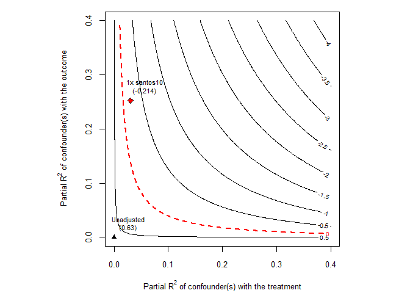

```r
plot(sense.model)
```

This contour graph is plotted against various values of $R^2_{Y\sim Z|D,X}$ and $R^2_{D\sim Z|X}$ (as you recall, these were the driving components in our updated bias term above). The level sets correspond to the treatment effect resulting from the appropriate combination of each partial R-squared. The black triangle is our *measured* treatment effect (0.63), while the red square is the *hypothesized* treatment effect due to a confounding variable with the explanability power of santos10.

Clearly, such a confounder would pose a serious problem to our regression analysis. In essense, the addition of that omitted variable would **reverse** our observed result–now increased deaths would correlate with a decreased support for the peace referendum!

## Political Treatment

The old model’s conclusion clearly lie on rather shaky ground. Thus Hazlett and Parente include an updated model, which we will now include.

```r
model2 <- lm(yes_vote~santos14+fat_2010to2013+elev+gdppc+pop13, data=colombia)
summary(model2)
```

```
##
## Call:
## lm(formula = yes_vote ~ santos14 + fat_2010to2013 + elev + gdppc +
##     pop13, data = colombia)
##
## Residuals:
##     Min      1Q  Median      3Q     Max
## -38.567  -6.570  -0.516   6.109  48.627
##
## Coefficients:
##                  Estimate Std. Error t value Pr(>|t|)
## (Intercept)     2.163e+01  1.189e+00  18.192  < 2e-16 ***
## santos14        6.668e-01  1.780e-02  37.455  < 2e-16 ***
## fat_2010to2013 -8.349e-03  2.209e-01  -0.038  0.96986
## elev           -1.142e-04  3.997e-04  -0.286  0.77513
## gdppc          -3.561e+01  1.139e+01  -3.126  0.00182 **
## pop13          -1.093e-05  2.481e-06  -4.407 1.16e-05 ***
## ---
## Signif. codes:  0 '***' 0.001 '**' 0.01 '*' 0.05 '.' 0.1 ' ' 1
##
## Residual standard error: 10.23 on 983 degrees of freedom
##   (134 observations deleted due to missingness)
## Multiple R-squared:  0.6557, Adjusted R-squared:  0.6539
## F-statistic: 374.4 on 5 and 983 DF,  p-value: < 2.2e-16
```

In the new model, the treatment has been changed to the percent of vote Santos received in 2014 (santos14)–perhaps political affiliation is a more important predictor for referendum support than is violence exposure. Clearly, this treatment is highly significant, so hopefully it proves to be equally robust. To check the sensitivity, we’re now using 2 benchmarks (GDP per Capita and Elevation), and magnifying their effects with a 3x multiplier.

```r
sense.model2 <- sensemakr(model2, treatment="santos14",
                          benchmark=c("gdppc","elev"),
                          kd=3)
sense.model2$sensitivity_stats
```

```
##   treatment  estimate         se t_statistic    r2yd.x      rv_q     rv_qa
## 1  santos14 0.6667991 0.01780262    37.45512 0.5879937 0.6779488 0.6600355
##     f2yd.x dof
## 1 1.427147 983
```

These values are in agreement with those of the paper. We can see a much improved $RV_{\alpha}$ compared to the old model; now an omitted variable would need to account for 66% of the outcome variation to remove the treatment significance. Similarly, the partial R-squared is much higher, pointing to a high level of robustness even in the event of an extreme confounder.

Let’s analyze the effects of our benchmarks using the contour plot:

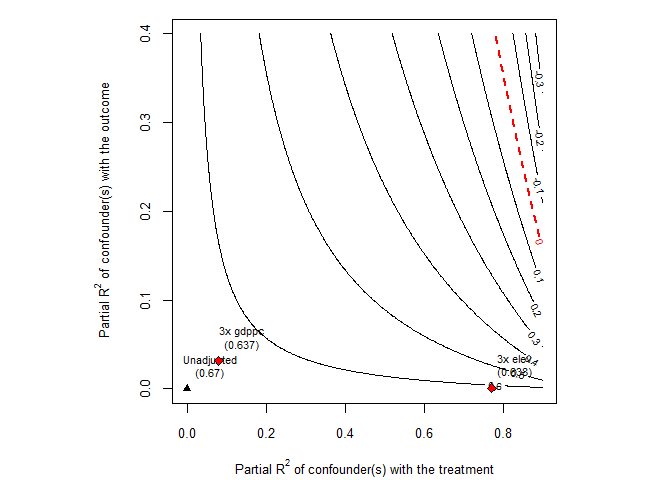

```r
plot(sense.model2, lim=0.9)
```

As you can see, even with variables 3 times the effects of our benchmark covariates, the predicted treatment effect would barely move, staying very close to it’s original value and never even approaching the “elimination” contour at 0. A confounding variable would need to be much more extreme than our known covariates to seriously affect the model results.

But let’s not leave out the worst case scenario. What would happen in the event of such an extreme confounder?

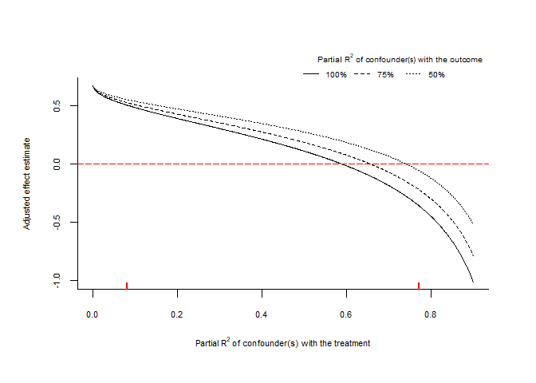

```r
plot(sense.model2, type="extreme", lim=0.9)
```

## Summary

As we have seen, proper sensitivity analysis can provide invaluable insights into the validity of regression analysis. While both treatments above would have passed the significance test at the 95% level, the results of the first model stood on very shaky ground, and conclusions could easily have been reversed by an unknown variable of the same magnitude as recorded covariates. In contrast, our second model was extremely robust to unknown data, and we may thus be much more confident that its results will not be overturned by the introduction of new variables.

There is one more remark I must make about sensitivity. Truthfully, much of our conclusions in this project came from comparing the robustness of two different models. Currently, there is no “gold standard” for a proper $RV$ score or partial R-squared (compared to, say, a p-value of 0.05). This is because omitted variable confounding can vary greatly among different fields of study, so it is difficult to immediately tell whether one of these scores is “good” or “bad.” Still, sensitivity analysis is an exciting area of ongoing research, and it will be interesting to see whether more concrete measures of robustness will be developed in the coming years.